# Basic building footprint calculations

June 10, 2020

While remote sensing has long been used to monitor urbanisation patterns, in recent years there has been an increasing availability in finer resolution satellite data covering large areas of the globe. This very high resolution imagery (often <1 m spatial resolution), combined with increased computing power is producing new datasets on urban areas. In particular, machine learning algorithms are being applied to detect, automatically extract, and map full sets of building features in a scene. These automated methods add to the manually digitised information such as from [OpenStreetMap](http://www.openstreetmap.org) and the property datasets available from some city governments.

Such building footprint datasets provide a new level of detail on urban areas, particularly in places which might otherwise lack detailed maps on cities and rapidly growing areas. Despite their spatial detail, building footprints typically lack any other attribute information to help differentiate land uses or other neighbourhood characteristics. However, the size, shape, orientation, and clustering of structures produces a spatial pattern that can suggest areas of different land use or activities.

```r
library(foot)
```

The `foot` package was developed by WorldPop at the University of Southampton (www.worldpop.org) to support geometric calculations and zonal summaries of measures from building footprint polygons. This vignette will demonstrate some of the core functionality in the package, including:

- The available measurements and summary statistics
- How to define different types of spatial zones for summaries
- Example workflows to produce tabular and gridded output

To demonstrate the package, this vignette will use a supplied sample of building footprint polygons produced by Microsoft Bing Maps ([Source](https://github.com/microsoft/Uganda-Tanzania-Building-Footprints)) from an area in Kampala, Uganda. These footprints have been reprocessed into a spatial data format which can be read with `sf`.

## Load the sample dataset

```r
data("kampala")

buildings <- kampala$buildings
adminzones <- kampala$adminZones
clusters <- kampala$clusters
```

Note that the adminZones and cluster boundaries are purely artificial and were created for demonstration purposes only.

For more information, see `?kampala`.

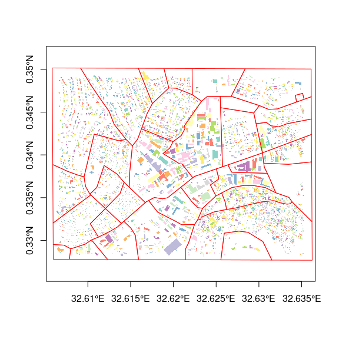

Sample buildings and zones in Kampala

## Calculations with `foot`

All function names for calculating metrics begin with `fs_` (short for “footprint statistic”). The second part of the name includes the group of measures (e.g. area or perimeter), and finally an abbreviation for the summary statistic (e.g. ‘cv’ for coefficient of variation or ‘sd’ for standard deviation).

### Available metrics and summary measures

Currently implemented are measures for:

- presence (binary and count)
- area
- perimeter
- Euclidean nearest neighbour distance
- nearest neighbour index
- angle of rotation
- compactness and shape indices

A table of metrics is available in the package `foot::fs_footprint_metrics`. Helper functions are also available to look up function names, groupings, and units. See `?get_fs_metrics`.

## Basic usage

The simplest usage of `foot` involves supplying a set of building footprints to the desired metric and summary function.

```r
# mean of all footprint areas
built_area <- fs_area_mean(buildings)
```

[output not shown]

```r
built_area
```

```
#>    index fs_area_ha_mean
#> 1:     1 0.02631865 [ha]
```

```r
# standard deviation of perimeters
perim_sd <- fs_perim_sd(buildings)
perim_sd
```

```
#>    index fs_perim__sd
#> 1:     1     58.46233
```

```r
# median of areas
area_med <- fs_area_median(buildings, unit = "m^2")
area_med
```

```
#>    index fs_area_m^2_median
#> 1:     1     118.3406 [m^2]
```

With no other argument supplied, all the footprints are treated as coming from the same zone for the summary. Default unit values are used for geometry measurements, unless otherwise specified (see third example). All functions return the same format - a `data.table` with a column for the index and the named column for the summarised footprint metric.

There is also an option to supply pre-calculated column to each function with the `col=` argument. If a pre-calculated geometry value exists, that field can be used or, if it is absent, the appropriate geometries needed for the metric will be calculated.

All functions follow the same parameter template, and, because the first argument is always data, all the functions allow for “piping” syntax.

```r
# random sample of buildings
result <- buildings %>%
          dplyr::filter(FID_1 %in% sample(FID_1, 1000)) %>%
          fs_area_mean()
# show the resulting table
result
```

```
#>    index fs_area_ha_mean
#> 1:     1 0.02672738 [ha]
```

Most low-level geometry calculations rely on `sf` and `lwgeom` and users need to have recent versions of these packages installed.

### Nearest neighbour distances

Distances can be calculated between footprints (represented as points or as polygons), between footprints and other objects, and/or within a maximum search distance.

```r
# nearest distance for the first 10 buildings to any other building measured
# between polygon edges
fs_nndist(buildings[1:10, ], buildings, maxSearch = 200, unit = "m")
```

```
#> although coordinates are longitude/latitude, st_intersects assumes that they are planar
#> Warning in st_centroid.sfc(sf::st_as_sfc(sf::st_bbox(X))): st_centroid does not
#> give correct centroids for longitude/latitude data
#> although coordinates are longitude/latitude, st_intersects assumes that they are planar
#> Units: [m]
#>  [1]  3.961359  7.894813  1.019971 22.306277  2.484471 16.257603  0.951225
#>  [8]  1.864305  2.607113  2.291474
```

```r
# omitting 'Y' measures distance among the footprints supplied
fs_nndist(buildings[1:10, ], maxSearch = NULL)  # unrestricted distance
```

```
#> although coordinates are longitude/latitude, st_intersects assumes that they are planar
#> Units: [m]
#>  [1]  83.55586  83.55586  72.16085  72.16085  94.94137  94.94137 202.23022
#>  [8] 209.11098 202.23022 417.35128
```

Note that distance calculations are slower for polygons and for unprojected coordinate systems. It is recommended that a maximum search radius is always used. Internally the calculations are done with a `data.table` to benefit from multithreading capabilities.

### Rotation angles

A less conventional geometric measure is derived from the rotated bounding rectangle. This is the rectangle enclosing a polygon (or set of points) which has been rotated to minimise the area. In contrast, a “bounding box” for a shape is always oriented along the x and y axes.

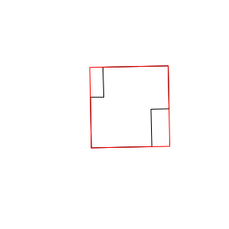

```r
# To obtain the rotated rectangle as a spatial object
mbr <- fs_mbr(buildings[5, ], returnShape = T)

plot(sf::st_geometry(buildings[5, ]))
plot(mbr, border = "red", add = T)
```

```r
# Or obtain just the angle
fs_mbr(buildings[5, ], returnShape = F)
```

```
#>        X
#> 358.8693
```

The angles can be summarised as an entropy measure and normalised to describe how much the angles of structures depart from a regular grid pattern (available in `fs_angle_entropy()`).

## Creating and supplying zone indices

Rather than treating all features as a single summary zone, it’s more common to want to summarise metrics within smaller areas. There are several ways to supply information on the zones.

### Index by vector

A vector of indices for a zone can be supplied to the functions as a column name, column number, or passed as a standalone vector object. The length of a vector of indices must match the number of building polygons.

```r
# create a vector of ten random zones
id <- sample(1:10, nrow(buildings), replace = T)
buildings$id <- id  # add it to the buildings object
table(buildings$id)  # splitting observations into 10 groups
```

```
#>
#>   1   2   3   4   5   6   7   8   9  10
#> 483 514 477 496 514 476 445 464 481 490
```

```r
# pass the index by name
fs_area_total(buildings, index = "id")  # note default units
```

```
#>     index fs_area_ha_total
#>  1:     1    10.86785 [ha]
#>  2:     2    15.03697 [ha]
#>  3:     3    10.82379 [ha]
#>  4:     4    13.09774 [ha]
#>  5:     5    15.59319 [ha]
#>  6:     6    13.49674 [ha]
#>  7:     7    12.78580 [ha]
#>  8:     8    11.49842 [ha]
#>  9:     9    12.73382 [ha]
#> 10:    10    11.44798 [ha]
```

```r
# pass the index by column number
fs_count(buildings, index = 3)
```

```
#>     index fs_count
#>  1:     1      483
#>  2:     2      514
#>  3:     3      477
#>  4:     4      496
#>  5:     5      514
#>  6:     6      476
#>  7:     7      445
#>  8:     8      464
#>  9:     9      481
#> 10:    10      490
```

```r
# pass a separate vector object
print(fs_angle_entropy(buildings, index = id, normalize = T))
```

```
#>     index fs_angle_entropy
#>  1:     1       0.06465623
#>  2:     2       0.04872999
#>  3:     3       0.08444432
#>  4:     4       0.06384505
#>  5:     5       0.05942041
#>  6:     6       0.06489796
#>  7:     7       0.07844943
#>  8:     8       0.06251966
#>  9:     9       0.07971051
#> 10:    10       0.06051774
```

### Index by shape

Rather than supplying a pre-calculated column or vector of zonal indices, buildings can be assigned a zone based on a spatial join. Creating an index from a spatial object returns a field called “zoneID” which other calculation functions in `foot` can use.

```r
# Return a table of index values based on administrative zone polygons
zID <- zonalIndex(buildings, adminzones, returnObject = F)
zID  # the xID column are row numbers
```

```
#>        xID zoneID
#>    1:  145      1
#>    2:  338      1
#>    3:  655      1
#>    4:  995      1
#>    5: 2869      1
#>   ---
#> 4846: 4829     34
#> 4847: 4830     34
#> 4848: 4831     34
#> 4849: 4832     34
#> 4850: 4833     34
```

```r
# Alternatively, join the zones to create and return a new spatial object A
# custom zone name can be added but must be supplied to the summary functions
zObj <- zonalIndex(buildings, clusters, zoneField = "Id", returnObject = T)
zObj
```

```
#> Simple feature collection with 350 features and 3 fields
#> geometry type:  POLYGON
#> dimension:      XY
#> bbox:           xmin: 32.60631 ymin: 0.328119 xmax: 32.63543 ymax: 0.349785
#> geographic CRS: WGS 84
#> First 10 features:
#>    FID_1 id Id                       geometry
#> 1   6293  7  1 POLYGON ((32.60744 0.338575...
#> 2  17706  7  1 POLYGON ((32.60664 0.339347...
#> 3  29106  6  1 POLYGON ((32.60719 0.339276...
#> 4  53393  7  1 POLYGON ((32.60779 0.339691...
#> 5  57187  1  1 POLYGON ((32.60826 0.338663...
#> 6  59496  9  1 POLYGON ((32.60692 0.339387...
#> 7  68588  5  1 POLYGON ((32.60791 0.338896...
#> 8  68590  9  1 POLYGON ((32.60768 0.339633...
#> 9  72387  3  1 POLYGON ((32.60777 0.338962...
#> 10 78504  2  1 POLYGON ((32.60702 0.338636...
```

When using a new spatial object which has been joined to its zones, remember to supply the name of the zone field if a custom name was used.

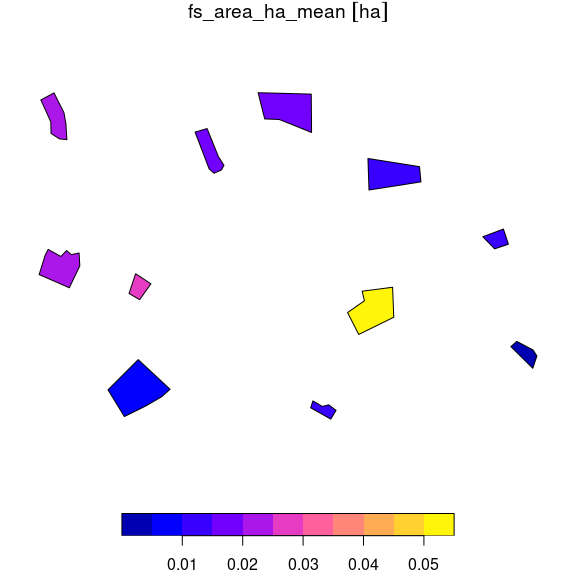

```r
# use the new object
zarea <- fs_area_mean(zObj, index = "Id")
clusters <- merge(clusters, zarea, by.x = "Id", by.y = "index")
plot(clusters["fs_area_ha_mean"])
```

The `zonalIndex` function works by spatial intersection. This produces some (potentially useful) side effects that users need to be aware of.

The default behaviour is for any intersecting structure to included in the zone.

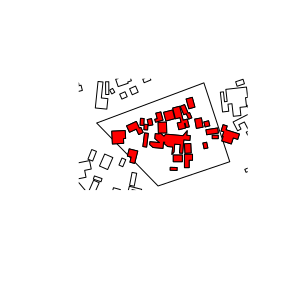

```r
# Note the selected structures extend beyond the cluster boundary
plot(sf::st_geometry(clusters)[[6]])
plot(sf::st_geometry(buildings), add = T)
plot(sf::st_geometry(zObj[zObj$Id == 6, ]), col = "red", add = T)
```

Alternatively, the intersection can return a clipped set of buildings.

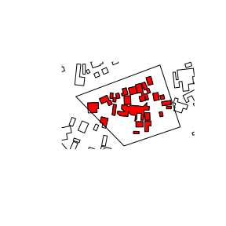

```r
zClip <- zonalIndex(buildings, clusters, zoneField = "Id", clip = T)

plot(sf::st_geometry(clusters)[[6]])
plot(sf::st_geometry(buildings), add = T)
plot(sf::st_geometry(zClip[zClip$Id == 6, ]), col = "red", add = T)
```

This option clips the footprints via intersection, potentially leaving small slivers of structures in the zone which will affect the feature statistics.

An additional side effect of the intersection is that overlapping zones are allowed and this duplicates and associates the footprints into both zones.

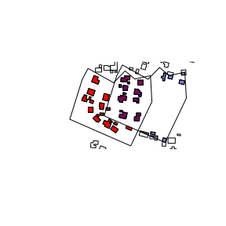

```r
# create a temporary shape by shifting one cluster
newClusters <- st_sfc(sf::st_geometry(clusters)[[1]], sf::st_cast(sf::st_geometry(clusters)[[1]] +
    c(0.001, 1e-04), "POLYGON"), crs = sf::st_crs(clusters))

newClusters <- st_sf(geometry = newClusters, crs = sf::st_crs(clusters))

newObj <- zonalIndex(buildings, newClusters, clip = T)

# areas of overlap are in a purple hue
plot(sf::st_geometry(newClusters))
plot(sf::st_geometry(newObj[newObj$zoneID == 1, ]), col = "red", add = T)
plot(sf::st_geometry(newObj[newObj$zoneID == 2, ]), col = sf::sf.colors(n = 1, alpha = 0.5),
    add = T)
plot(sf::st_geometry(buildings), add = T)
```

These side effects are allowed because they allow for flexibility to support types of “focal” summaries of statistics and to produce a true gridded measure of footprint metrics.

## Calculating multiple metrics

The `calculate_footstats()` function provides a convenient wrapper to the individual footprint statistic functions and other helper functions. The function accepts a variety of input formats (see `?calculate_footstats`). Multiple metrics can be calculated for the same sets of buildings and zones.

```r
# Creates zonal index and calculates multiple metrics
results <- calculate_footstats(buildings,
                               adminzones,
                               metrics=c("fs_area_mean","fs_area_cv"),
                               gridded=F)
```

```
#> although coordinates are longitude/latitude, st_intersects assumes that they are planar
```

```r
  print(results)
```

```
#>     index  fs_area_ha_mean       fs_area_cv
#>  1:     1 0.040259838 [ha] 1.2479809 [1/ha]
#>  2:     2 0.021105341 [ha] 1.1069491 [1/ha]
#>  3:     3 0.052507469 [ha] 1.9194754 [1/ha]
#>  4:     4 0.055509314 [ha] 3.8206699 [1/ha]
#>  5:     5 0.056871544 [ha] 1.7000587 [1/ha]
#>  6:     6 0.102195294 [ha] 2.0652377 [1/ha]
#>  7:     7 0.202770402 [ha] 1.4077033 [1/ha]
#>  8:     8 0.090824803 [ha] 1.4225521 [1/ha]
#>  9:     9 0.018168220 [ha] 1.6104922 [1/ha]
#> 10:    10 0.025199721 [ha] 1.5272718 [1/ha]
#> 11:    11 0.022011253 [ha] 1.4300230 [1/ha]
#> 12:    12 0.008783690 [ha] 1.2659928 [1/ha]
#> 13:    13 0.066161890 [ha] 1.7191007 [1/ha]
#> 14:    14 0.008185444 [ha] 0.3447115 [1/ha]
```

[output cut: 20 more lines]

Note that this function uses the default arguments and units for creating zones and calculating metrics. For the requested metrics the standard deviation is required for the CV calculation. This is dependency is added and handled internally by `calculate_footstats`. Also note that one zone has only one structure in it, so NA values are returned for the CV.

The argument `metrics` will accept a string or a vector of strings for specific metric names. Users may also supply `"ALL"` or `"NODIST"` to calculate all available metrics or all bar the nearest neighbour distance-related ones, respectively.

## Gridded outputs

Often the desired output is a gridded dataset of a measure, rather than summarising metrics to polygon zones. A gridded dataset can be achieved with the `foot` functions in several ways.

1. The simplest method is to attach buildings (and summary measures) to grid cells by their centroid point location. A fast approach is to use cell numbers as a zonal index.

```r
mgrid <- kampala$mastergrid # ~100m raster layer

# get the cell numbers from the grid
cellIDs <- raster::cellFromXY(mgrid,
                              sf::st_coordinates(sf::st_centroid(buildings)))
# use these numbers as the zone
gridRes <- calculate_footstats(buildings,
                               index=cellIDs,
                               metrics=c("fs_perim_total",
                                         "fs_area_total",
                                         "fs_count",
                                         "fs_settled"),
                               gridded=F)
# buildings lacking a grid cell are NA
gridRes <- na.omit(gridRes)
  gridRes
```

```
#>      index fs_perim__total fs_area_ha_total fs_count fs_settled
#>   1:     1    79.27521 [m] 0.030170228 [ha]        1          1
#>   2:     2   275.12308 [m] 0.112942319 [ha]        4          1
#>   3:     3   356.61070 [m] 0.138862915 [ha]        5          1
#>   4:     4   351.05542 [m] 0.128857046 [ha]        6          1
#>   5:     5   209.95544 [m] 0.069463158 [ha]        3          1
#>  ---
#> 781:   892   247.10057 [m] 0.090691170 [ha]        4          1
#> 782:   893   317.01344 [m] 0.191112517 [ha]        2          1
#> 783:   897   236.90637 [m] 0.059662965 [ha]        6          1
#> 784:   898   166.82738 [m] 0.042424995 [ha]        4          1
#> 785:   900    38.63609 [m] 0.008472198 [ha]        1          1
```

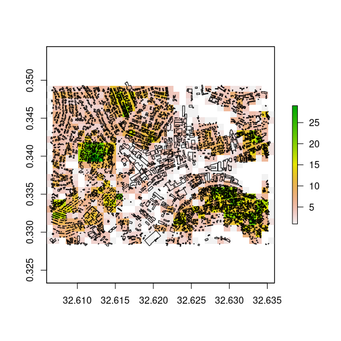

```r
# create a blank raster and fill with summary measures
outSettled <- mgrid
outSettled[] <- NA
# `$index` are the cell numbers from the raster
outSettled[gridRes$index] <- gridRes$fs_area_ha_total

outCount <- mgrid
outCount[] <- NA
outCount[gridRes$index] <- gridRes$fs_count

raster::plot(outCount)
plot(sf::st_geometry(buildings), add=T)
```

2. Pixel-level calculation. While centroid-based calculations are fast, sometimes it may be necessary to know the true amount of settlement *per pixel*. The zonal index functions can be used to intersect buildings to grid squares, and then supply those “pixels” as zones to the feature calculations as shown.

```r
# convert the grid to a `stars` object and then `sf` to get polygons
sgrid <- stars::st_as_stars(mgrid)
sgrid <- sf::st_as_sf(sgrid)

# add a cell number ID to the grid polygons
sgrid$cellIDs <- raster::cellFromXY(mgrid, sf::st_coordinates(sf::st_centroid(sgrid)))

# create a zonal index on the building objects
pxZone <- zonalIndex(buildings,
                     sgrid,
                     "cellIDs",
                     returnObject=T,
                     clip=T)

pxResult <- calculate_footstats(pxZone,
                                index="cellIDs",
                                metrics=c("fs_area_total", "fs_settled"))
  print(pxResult)
```

```
#>      index  fs_area_ha_total fs_settled
#>   1:     1 2.676570e-02 [ha]          1
#>   2:     2 1.086126e-01 [ha]          1
#>   3:     3 1.509693e-01 [ha]          1
#>   4:     4 1.539263e-01 [ha]          1
#>   5:     5 6.933793e-02 [ha]          1
#>  ---
#> 835:   894 4.767962e-05 [ha]          1
#> 836:   897 6.184597e-02 [ha]          1
#> 837:   898 3.986828e-02 [ha]          1
#> 838:   899 1.304506e-03 [ha]          1
#> 839:   900 6.687084e-03 [ha]          1
```

As before, the metrics are linked to the grid by their cell numbers. The results can also be merged to the `stars` or `sf` representation of the grid and quickly rasterized based on geometry. The difference between using centroids or pixels is most visible with large structures.

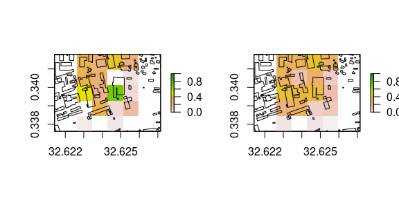

Centroid-based (left) and a pixel-based (right) map of total building area

```r
# create output
pxSettled <- mgrid
pxSettled[] <- NA
pxSettled[pxResult$index] <- pxResult$fs_area_ha_total

# compare centroid and pixel settled maps
par(mfrow = c(1, 2))
raster::plot(outSettled, zlim = c(0, 1), xlim = c(32.623, 32.626), ylim = c(0.338,
    0.342))
plot(sf::st_geometry(buildings), add = T)
raster::plot(pxSettled, zlim = c(0, 1), xlim = c(32.623, 32.626), ylim = c(0.338,
    0.342))
plot(sf::st_geometry(buildings), add = T)
```

3. Write gridded data to GeoTiff files. Using `calculate_footstats` a template raster and an output location can be specified. The template can be a `raster` or `stars` object. Each metric will be written to a separate grid. This approach builds on using an `sf` object to define the summary zone directly in the call to the wrapper function.

```r
outputPath <- tempdir()

# re-using the sf pixels as "zones"
calculate_footstats(buildings,
                    index=sgrid,
                    metrics=c("fs_area_mean", "fs_settled"),
                    gridded=TRUE,
                    template=mgrid,  # using a rasterlayer
                    outputPath=outputPath # or a temp directory is created
                   )
```

```
#> although coordinates are longitude/latitude, st_intersects assumes that they are planar
#> Warning in dir.create(outputPath): '/tmp/RtmpBMnA1x' already exists
#>      index  fs_area_ha_mean fs_settled
#>   1:     1 0.030170228 [ha]          1
#>   2:     2 0.027039204 [ha]          1
#>   3:     3 0.024465687 [ha]          1
#>   4:     4 0.026389713 [ha]          1
#>   5:     5 0.023045401 [ha]          1
#>  ---
#> 835:   894 0.146420223 [ha]          1
#> 836:   897 0.011029982 [ha]          1
#> 837:   898 0.011290191 [ha]          1
#> 838:   899 0.010422231 [ha]          1
#> 839:   900 0.008472198 [ha]          1
```

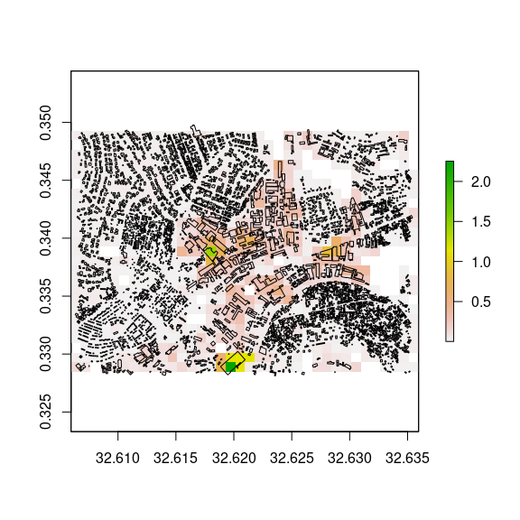

```r
# get the output
raster::plot(raster::raster(paste0(outputPath, "/fs_area_ha_mean.tif")))
plot(st_geometry(buildings), add=T)
```

The above approaches work fine for small study areas, but may be too slow over large areas and with many footprint features. Producing country-scale gridded datasets with tools from `foot` is addressed in the second vignette (“bigfoot”).